# Smooth Scatter Tutorial

## Intro

In this blog, I will show you how to create a smooth scatter using ggplot2. Smooth scatter is basically a scatter plot, but shows a general estimation of the density of the data. This is great for getting a general idea of where data is centered. It is also great for eliminating outliers, as they are not dense.

## Tutorial

You will first need to install and load the **ggplot2** and **MASS** packages in R:

```
install.packages("ggplot2")
install.packages("MASS")
library(ggplot2)
library(MASS)
```

Then, I will genereate some random data that will work well for a smooth scatter plot:

```
set.seed(2)
data <- data.frame(mvrnorm(n = 1000, mu = c(0, 0), Sigma = matrix(rep(c(1, 0.2), 2), nrow = 2, ncol = 2)))
names(data) <- c("x", "y")
```

The first step to greating the smooth scatter plot is generating the layers that will be used for density estimation. This can be done with the ggplot function like such:

```
ggplot(data = data, aes(x, y)) + stat_density2d(aes(fill = ..density..^0.25), geom = "tile", contour = FALSE, n = 200) + scale_fill_continuous(low = "white", high = "dodgerblue4")
```

Producing this plot:

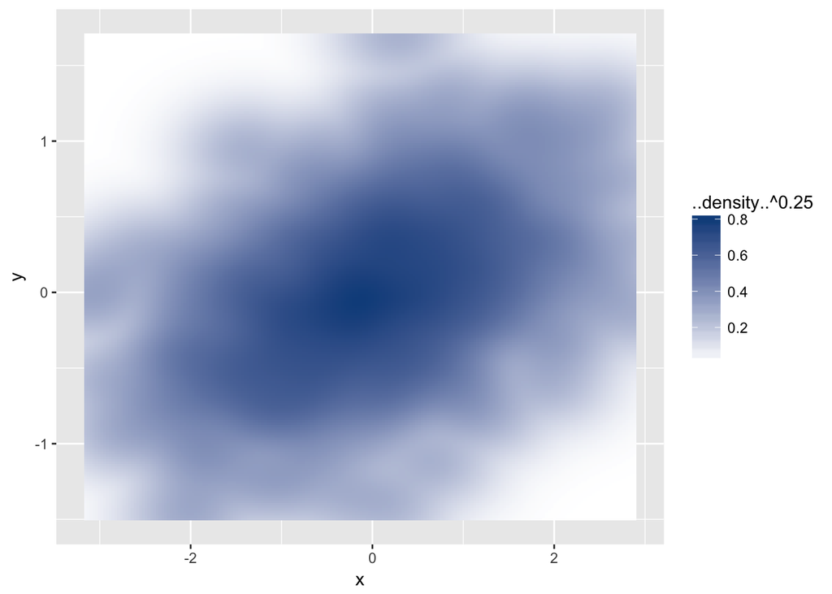

To make the data points visable, you can add (+) the geom_point function to your ggplot and set the alpha to be whatever you want. I will use alpha = 0.1:

```
last_plot() + geom_point(alpha = 0.1, shape = 20)
```

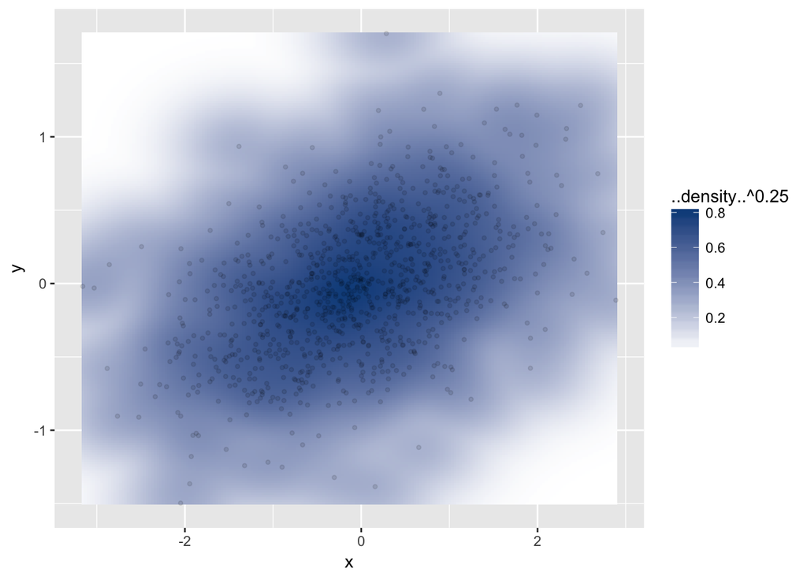

Note that the blue is darker in areas of more data points, and lighter blue in areas with less data points and outliers. Now you have created a smooth scatter plot

## Customization

Like any experienced developer, you may want to change the theme of your plot. You can change the colors and labels using the parameters in the code above, but you can even use the themes library to customize your plot. For example:

```
install.packages("ggthemes")
```

[output not shown]

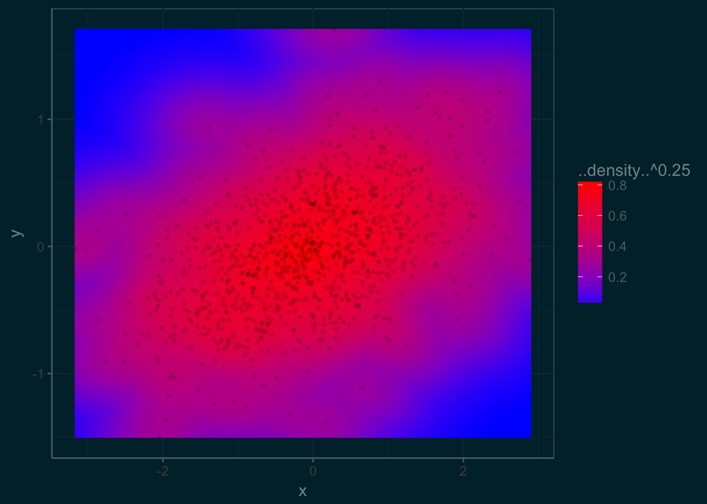

```r
library(ggthemes)
last_plot() + theme_solarized(light = FALSE) + scale_fill_continuous(low = "blue", high = "red")
```